# Data Analysis Section 3 - Community assembly on a functional basis

Author

Sylvain Schmitt

Published

October 22, 2026

```r
library(tidyverse)
library(knitr)
library(ggfortify)
options(knitr.kable.NA = "")
```

In today’s exercise, we will analyse a dataset from the Ducke Reserve to understand the functional structure of the understorey tree community. You will have already realised that the central Amazon is not flat, and the Ducke Reserve is a good example of this. Previous studies have shown that topographical variation is an important factor controlling species distribution and various ecosystem processes. However, ‘topography’ is a complex gradient involving changes in altitude, slope, soil, water and other properties associated with these factors. The figures below illustrate these relationships:

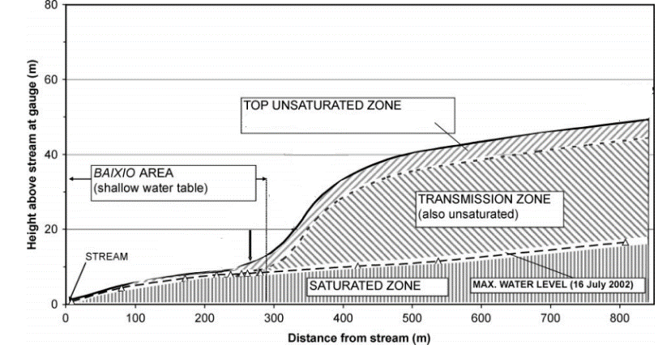

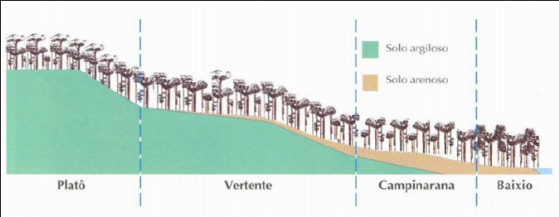

The higher parts of the terrain (plateaus) are clayey (~90 per cent clay) and this proportion decreases towards the lower-lying areas (lowlands), where the soil can contain up to 95 per cent sand. Nutrient levels decrease towards the sandier areas, whilst soil moisture is more abundant in the lower-lying areas, where the water table is shallow or near the surface, causing waterlogging. Thus, we can say that the topographical gradient represents a hydro-edaphic gradient, ranging from clayier, less moist and slightly more fertile soils to sandier soils that are constantly waterlogged and infertile.

The analyses will be based on classical community assembly and functional ecology approaches (community-weighted means), building on the work of Schmitt et al. (2021) .

# Data

The database we will be using consists of 1,658 tree individuals with a DBH of between 1 and 5 cm, sampled from 20 plots measuring 1 x 250 m. In each plot, all individuals were recorded and measured; therefore, the mean value of each functional characteristic for the community does not need to take into account mean values for the species.

## Community

The “**traits for analysis.xlsx**” table contains data on the functional characteristics of the individuals. Each row in the table represents an individual, with their corresponding measurements. The ‘Plot’ column indicates which plot the individual belongs to. Light measurements above the canopy and total tree height (height) were taken for each plant and can be used to derive an average light measurement or height for the plot. For each individual, trait values are detailed below with code and unit:

| Code | Unit | Name |
| --- | --- | --- |
| BarkDMC |  | branch dry matter content |
| BarkProp |  |  |
| BarkT |  | branch bark thickness |
| BWD | g/cm³ | branch wood density |
| FPs |  |  |
| LAR |  |  |
| AFAX |  | the ratio of leaf area to xylem area |
| LDMC | mg/g | leaf dry matter content |
| LS |  |  |
| LT | cm | leaf thickness |
| PDMC |  |  |
| PP |  | branch core/pit proportion |
| SBL |  |  |
| SLA | m²/kg | specific leaf area |
| WD |  | wood density |
| PX |  | branch xylem proportion |

> NB: traits need to be filtered and selected and described.

```r
com <- readxl::read_xlsx("data/traits for analysis.xlsx") |>
  mutate(across(SBL:LightTree, as.numeric)) |>
  mutate(Plot = gsub("_", "T", Plot)) |>
  mutate(Plot = ifelse(Plot == "LO6T500", "LO6T0500", Plot)) |>
  select(-LMA, -FP, -Chl, -BLABL, -LMF, -LD, -Family, -Genus, -Epitet,
         -BarkD, -WDMC) |>
  rename(BWD = BranchDensity, PX = XylProp, PP = PithProp, AFAX = LAXA,
         Tree = `# arvore`, Species = Species_new)
com |>
  head() |>
  kable()
```

| Tree | Plot | Species | SBL | WD | BarkDMC | BWD | PP | PX | BarkProp | BarkT | AFAX | LAR | LS | LT | SLA | LDMC | PDMC | FPs | Height | LightTree |
| --- | --- | --- | --- | --- | --- | --- | --- | --- | --- | --- | --- | --- | --- | --- | --- | --- | --- | --- | --- | --- |
| 1904 | LO2T1000 | Cybianthus na | 13.86 | 0.77 | 485.88 | 0.66 |  |  |  |  |  |  | 68.79 | 0.20 | 9.76 | 525.61 | 499.28 | 217.77 | 3.0 | 1.0 |
| 1913 | LO2T1000 | Siparuna guianensis | 13.44 | 0.59 | 332.32 | 0.50 |  |  |  |  |  |  | 52.73 | 0.21 | 15.38 | 344.22 | 294.99 | 128.83 | 9.0 | 1.0 |
| 1917 | LO2T1000 | Licania sothersae | 11.43 | 0.73 | 510.50 | 0.63 |  |  |  |  |  |  | 37.11 | 0.19 | 12.77 | 438.13 | 423.98 | 234.15 | 8.0 | 1.0 |
| 1921 | LO2T1000 | Tetragastris panamensis |  |  |  |  |  |  |  |  |  |  | 406.18 | 0.20 | 12.59 | 517.62 | 551.77 | 238.37 | 5.0 | 1.0 |
| 1922 | LO2T1000 | Duguetia flagellaris | 12.41 | 0.73 | 432.71 | 0.56 |  |  |  |  |  |  | 86.27 | 0.18 | 13.92 | 462.14 | 523.08 | 238.88 | 2.9 | 1.0 |
| 1930 | LO2T1000 | Hirtella duckei | 24.39 | 0.56 | 417.61 | 0.52 |  |  |  |  |  |  | 88.77 | 0.15 | 18.42 | 470.75 | 406.36 | 244.35 | 6.0 | 1.5 |

## Environment

The “**DadosAmbiente.csv**” table contains data on the environmental characteristics for each plot. For each plot, there is data on altitude (m), vertical distance above the drainage level (HAND30, in m, an indirect measure of soil drainage), slope (in degrees), exchangeable base content (sum of Ca, Mg, K, in cmol/kg), and the percentage of clay, sand and silt.

```r
env <- readxl::read_xls("data/plotsducke_ambientes_completo2.xls",
                        "scores_amb_quasela") |>
  select(parcela, classcampo,
         altitude, Inclinacao, hand30,
         bases_cmolkg, P_1_mg_kg,
         Argila,    Silte,  Areia) |>
  rename(Plot = parcela, Habitat = classcampo,
         Altitude = altitude, Inclination = Inclinacao,
         HAND = hand30, Bases = bases_cmolkg, P = P_1_mg_kg,
         Clay = Argila, Silt = Silte, Sand = Areia)
env |>
  head() |>
  kable()
```

| Plot | Habitat | Altitude | Inclination | HAND | Bases | P | Clay | Silt | Sand |
| --- | --- | --- | --- | --- | --- | --- | --- | --- | --- |
| LO1T0000 | vertente | 85.044 | 22.33 | 8.369046 | 0.146 | 2.443 | 44.14 | 3.71 | 52.15 |
| LO1T1000 | plato | 108.478 | 0.83 | 37.888496 | 0.336 | 3.954 | 85.14 | 3.53 | 11.33 |
| LO1T2000 | plato | 109.771 | 2.17 | 26.991323 | 0.343 | 2.925 | 85.14 | 2.81 | 12.05 |
| LO1T3000 | plato | 104.504 | 4.67 | 37.137986 | 0.296 | 3.472 | 84.64 | 2.45 | 12.92 |
| LO1T4000 | plato | 89.171 | 7.17 | 27.557817 | 0.271 | 3.311 | 72.87 | 3.60 | 23.00 |
| LO1T5500 | vertente | 70.357 | 20.00 | 17.349024 | 0.168 | 3.826 | 43.92 | 3.60 | 52.48 |

# Analyses - CWM

Corresponding notions to be introduced in the lecture:

- Ordination and PCA?
- Community Weighted Means
- Means comparisons (Student’T test)
- Linear regressions

## Environmental co-variations

First, we examined the co-variations of environmental variables and found that they explained 71% of the variation across the two main axes (among 8 variables):

We will summarise the two main axes with representative variables: heigh above nearest drainage (HAND, m) and soil phosphorous content (mg/kg).

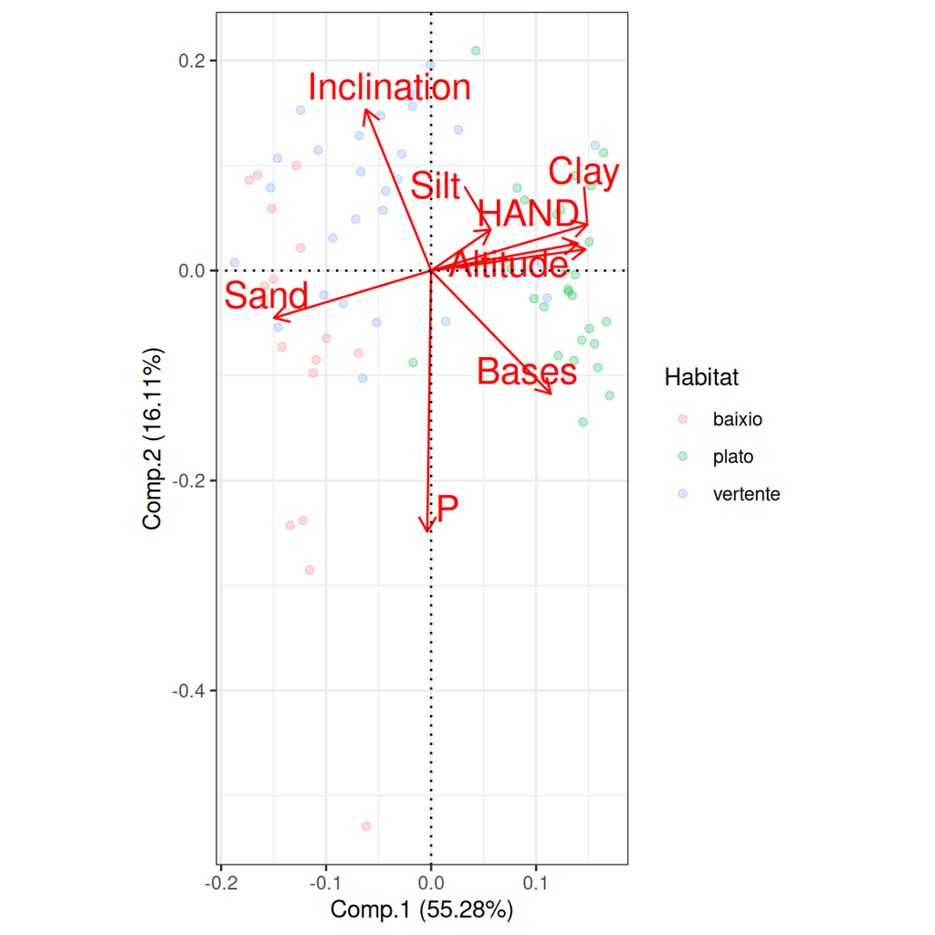

```r
autoplot(princomp(select(env, -Plot, -Habitat),
                  cor = TRUE),
         data = env, alpha = 0.25, col = "Habitat",
         loadings.label.size = 6,
         loadings.label.colour = 'red', loadings.label.vjust = 1.1,
         loadings.label.repel   = TRUE,
         loadings = T, loadings.label = T, loadings.colour = 'red') +
  coord_equal() +
  geom_hline(aes(yintercept = 0), col = 'black', linetype = "dotted") +
  geom_vline(aes(xintercept = 0), col = 'black', linetype = "dotted") +
  theme_bw()
```

## Traits co-variations

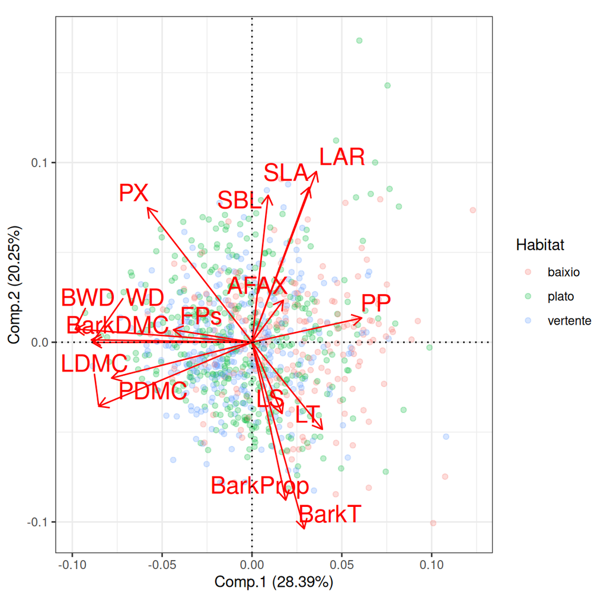

```r
pca_data <-  na.omit(com)
autoplot(princomp(select(pca_data, -Tree, -Plot, -Species,
                         -Height, -LightTree),
                  cor = TRUE),
         data = pca_data |> left_join(env), alpha = 0.25,
         loadings.label.size = 6, col = "Habitat",
         loadings.label.colour = 'red', loadings.label.vjust = 1.1,
         loadings.label.repel   = TRUE,
         loadings = T, loadings.label = T, loadings.colour = 'red') +
  coord_equal() +
  geom_hline(aes(yintercept = 0), col = 'black', linetype = "dotted") +
  geom_vline(aes(xintercept = 0), col = 'black', linetype = "dotted") +
  theme_bw()
```

## Community Weighted Means (CWM)

We calculated the community weighted mean trait value per plot for each trait:

$$CWM_t=\frac1N \sum_{i=1}^N value_{t,i}$$

where *value<sub>t</sub>*<sub>,*j*</sub> is the trait value of individual *i* for trait *t*.

```r
cwm <- com |>
  select(-Tree, -Species, -Height, -LightTree) |>
  group_by(Plot) |>
  summarise_all(mean, na.rm = TRUE)
cwm |>
  head() |>
  kable()
```

| Plot | SBL | WD | BarkDMC | BWD | PP | PX | BarkProp | BarkT | AFAX | LAR | LS | LT | SLA | LDMC | PDMC | FPs |
| --- | --- | --- | --- | --- | --- | --- | --- | --- | --- | --- | --- | --- | --- | --- | --- | --- |
| LO2T1000 | 14.11514 | 0.7554167 | 512.2331 | 0.5783099 |  |  |  |  |  |  | 204.3525 | 0.2040741 | 13.97228 | 435.0435 | 388.4927 | 198.9927 |
| LO2T2000 | 14.63039 | 0.6281176 | 416.0945 | 0.5404762 | 0.1098824 | 0.5582353 | 0.3318824 | 0.0464118 | 1.631177 | 107.1584 | 193.2844 | 0.1923529 | 13.76024 | 445.7546 | 379.1584 | 218.1414 |
| LO3T1500 | 18.05433 | 0.5980769 | 404.6294 | 0.5184762 | 0.1412308 | 0.5404615 | 0.3176923 | 0.0507923 | 1.753437 | 102.8988 | 212.5133 | 0.2011927 | 12.87796 | 456.1688 | 366.0097 | 184.7609 |
| LO3T2500 | 14.37088 | 0.6010256 | 416.0500 | 0.5341558 | 0.1500000 | 0.5766667 | 0.2733333 | 0.0483333 | 1.635000 | 88.8750 | 166.8888 | 0.2096341 | 13.27198 | 439.1893 | 368.3051 | 194.4063 |
| LO3T3500 | 18.40375 | 0.4693443 | 317.1652 | 0.4013115 | 0.1968333 | 0.4580000 | 0.3455000 | 0.0543542 | 2.202909 | 126.1144 | 197.6212 | 0.2098361 | 14.89182 | 369.2145 | 290.9532 | 210.4603 |
| LO3T4500 | 13.06686 | 0.6135294 | 436.0800 | 0.5423077 | 0.0926923 | 0.5415385 | 0.3657692 | 0.0521490 | 1.852115 | 118.6749 | 172.3869 | 0.1721154 | 15.44038 | 441.1192 | 385.8356 | 234.3786 |

## Habitats comparisons

Following Schietti et al. (2013), we used a HAND value of 18 m to distinguish between bottomlands and plateaus, and then compared the CWM values of the different habitats using a Student’s t-test. We identified the following significant differences between the different habitats:

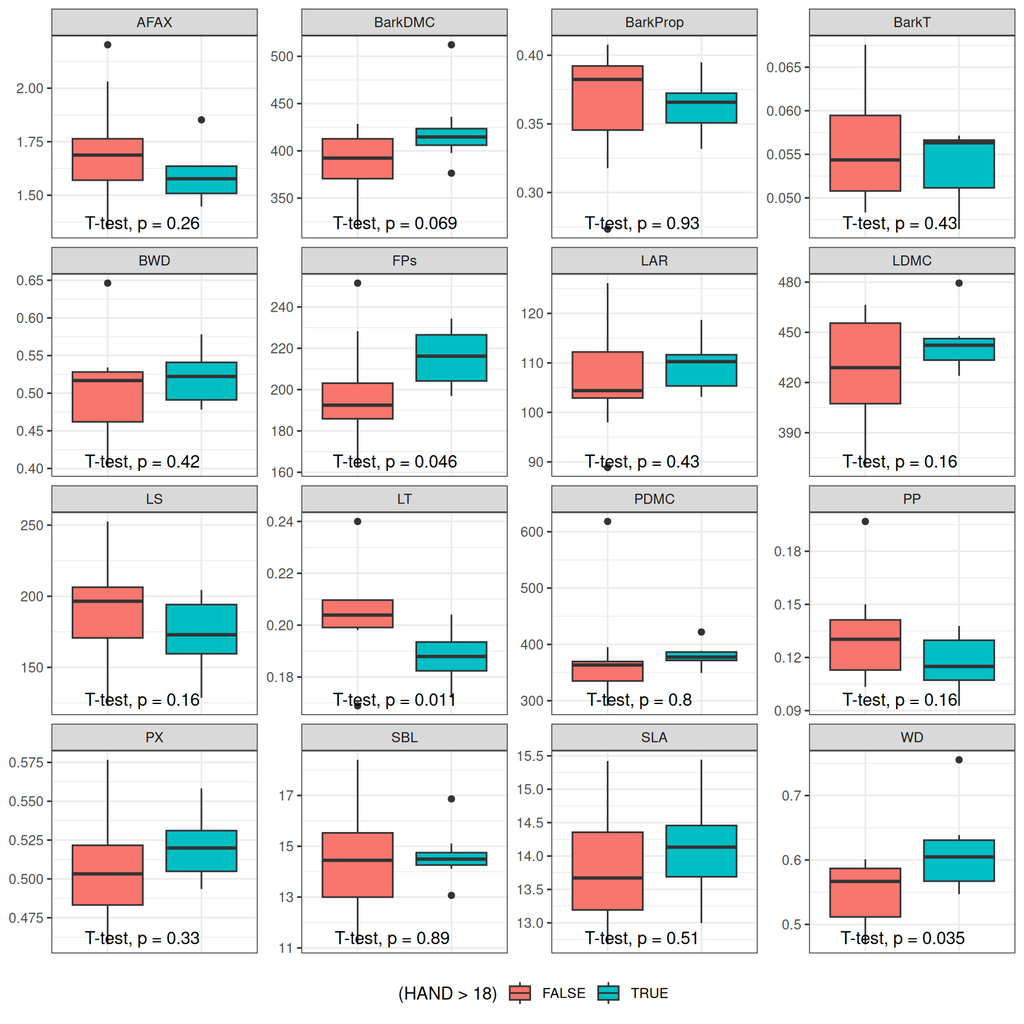

```r
cwm |>
  gather(trait, trait_value, -Plot) |>
  left_join(env) |>
  filter(!is.na(HAND)) |>
  ggplot(aes((HAND > 18), trait_value, fill = (HAND > 18))) +
  geom_boxplot() +
  facet_wrap(~ trait, scales = "free_y") +
  theme_bw() +
  theme(axis.title = element_blank(),
        legend.position = "bottom",
        axis.text.x = element_blank(),
        axis.ticks.x = element_blank()) +
  ggpubr::stat_compare_means(method = "t.test", label.y.npc = "bottom")
```

## Linear regressions

Finally, we performed linear regressions for each trait against two environmental variation variables, selected based on the co-variation of environmental variables: height above the nearest drainage (HAND) and phosphorus (P). We got 6 significant effects:

- BarkDMC increases with HAND
- BarkProp increases with phosphorous
- LDMC increases with HAND
- LT decreases with HAND
- PP decreases with HAND
- WD increases with HAND

Figures and tables below are showing:

1. the standard effect sizes for all regressions,
2. summary tables for LT and WD (other could be chosen),
3. and traits responding to HAND and P.

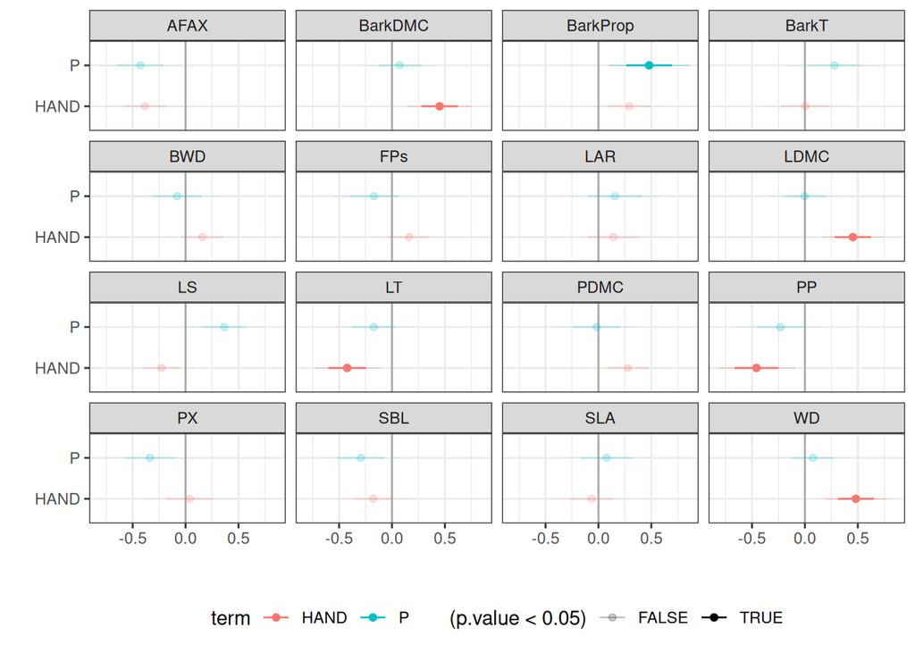

```r
all_reg <- cwm |>
  mutate(across(-Plot, ~ as.numeric(scale(.x)))) |>
  gather(trait, trait_value, -Plot) |>
  left_join(env |>
              mutate(HAND = log(HAND)) |>
              mutate(across(Altitude:Sand, ~ as.numeric(scale(.x))))) |>
  group_by(trait) %>%
  nest() |>
  mutate(
    model = map(data, ~ lm(trait_value ~ HAND + P, data = .x))
  )
all_reg |>
  mutate(coefs = map(model, ~broom::tidy(.x, conf.int = TRUE, conf.level = 0.90))) %>%
  unnest(coefs) |>
  select(-data, -model) |>
  filter(term != "(Intercept)") |>
  ggplot(aes(x = term, col = term, alpha = (p.value < 0.05))) +
  geom_hline(yintercept = 0, col = "darkgrey") +
  geom_point(aes(y = estimate)) +
  geom_segment(aes(y = estimate - std.error, yend = estimate + std.error)) +
  geom_segment(aes(y = conf.low, yend = conf.high), linewidth = .1) +
  facet_wrap(~trait) +
  theme_bw() +
  coord_flip() +
  xlab("") + ylab("") +
  scale_alpha_manual(values = c(0.2, 1)) +
  theme(legend.position = "bottom")
```

```r
sjPlot::tab_model(filter(all_reg, trait %in% c("LT", "WD"))$model,
                  dv.labels = filter(all_reg, trait %in% c("LT", "WD"))$trait)
```

|  | WD |  |  | LT |  |  |
| --- | --- | --- | --- | --- | --- | --- |
| Predictors | Estimates | CI | p | Estimates | CI | p |
| (Intercept) | 0.20 | -0.24 – 0.64 | 0.355 | -0.19 | -0.65 – 0.28 | 0.407 |
| HAND | 0.48 | 0.13 – 0.84 | **0.011** | -0.42 | -0.80 – -0.05 | **0.029** |
| P | 0.08 | -0.34 – 0.49 | 0.704 | -0.17 | -0.61 – 0.26 | 0.415 |
| Observations | 20 |  |  | 20 |  |  |
| R<sup>2</sup> / R<sup>2</sup> adjusted | 0.328 / 0.249 |  |  | 0.252 / 0.164 |  |  |

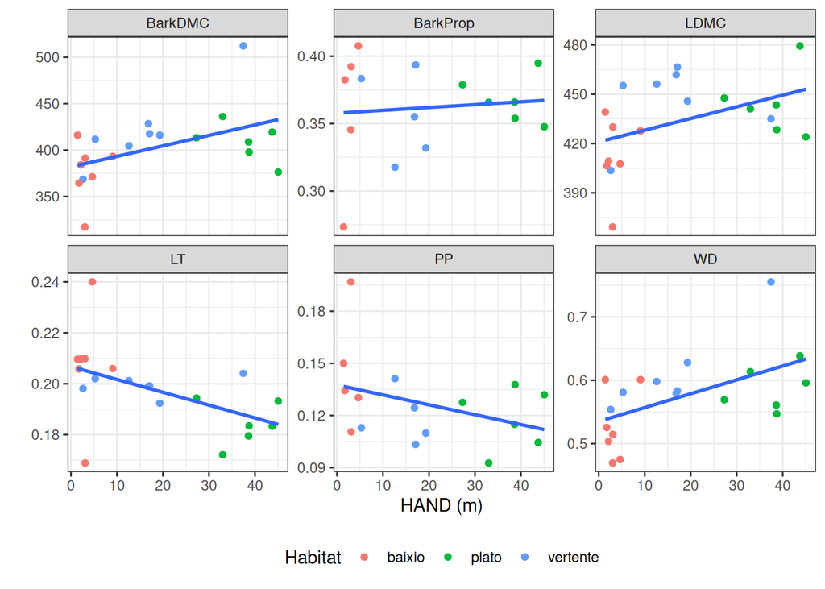

```r
cwm |>
  gather(trait, trait_value, -Plot) |>
  left_join(env) |>
  gather(env, env_value, -Plot, -Habitat, -trait, -trait_value) |>
  filter(trait %in% c("BarkDMC", "BarkProp", "LDMC", "LT", "PP", "WD"),
         env == "HAND") |>
  ggplot(aes(env_value, trait_value)) +
  geom_point(aes(col = Habitat)) +
  theme_bw() +
  facet_wrap(~ trait, scales = "free_y") +
  geom_smooth(method = "lm", se = FALSE) +
  ylab("") + xlab("HAND (m)") +
  theme(legend.position = "bottom")
```

# Analyses - CWV

## Community Weighted Variance (CWM)

We calculated the community weighted mean trait value per plot for each trait:

$$CWV_t= \frac1N \sum_{i=1}^N (value_{t,i} - CWM_t)^2$$

where *value<sub>t</sub>*<sub>,*j*</sub> is the trait value of individual *i* for trait *t* and *CWM<sub>t</sub>* the community weighted mean of the trait.

```r
cwv <- com |>
  select(-Tree, -Species, -Height, -LightTree) |>
  gather(Trait, Value, -Plot) |>
  group_by(Trait, Plot) |>
  mutate(CWM = mean(Value, na.rm = TRUE)) |>
  mutate(Diff2 = (Value-CWM)^2) |>
  summarise(CWV = mean(Diff2, na.rm = TRUE)) |>
  pivot_wider(names_from = Trait, values_from = CWV)
cwv |>
  head() |>
  kable()
```

| Plot | AFAX | BWD | BarkDMC | BarkProp | BarkT | FPs | LAR | LDMC | LS | LT | PDMC | PP | PX | SBL | SLA | WD |
| --- | --- | --- | --- | --- | --- | --- | --- | --- | --- | --- | --- | --- | --- | --- | --- | --- |
| LO2T1000 |  | 0.0756028 | 308871.117 |  |  | 5424.108 |  | 5526.612 | 107542.36 | 0.0022957 | 5331.831 |  |  | 51.31900 | 14.04575 | 1.8453498 |
| LO2T2000 | 0.9585892 | 0.0095783 | 6887.537 | 0.0127659 | 0.0008165 | 6107.612 | 1046.0478 | 5199.280 | 42607.62 | 0.0020580 | 8768.494 | 0.0065470 | 0.0128922 | 86.60580 | 14.89337 | 0.0162435 |
| LO3T1500 | 1.6351538 | 0.0187253 | 7568.244 | 0.0145162 | 0.0014181 | 3866.235 | 787.2483 | 5834.863 | 52691.02 | 0.0021169 | 10117.278 | 0.0125708 | 0.0247859 | 128.02592 | 11.20585 | 0.0255982 |
| LO3T2500 | 0.2629583 | 0.0128788 | 8954.487 | 0.0109889 | 0.0013302 | 3938.013 | 1064.6948 | 5204.257 | 17943.47 | 0.0020499 | 10139.777 | 0.0111667 | 0.0345222 | 156.43474 | 13.40529 | 0.0175015 |
| LO3T3500 | 3.1536024 | 0.0145130 | 10280.443 | 0.0139047 | 0.0019973 | 5804.063 | 1192.1495 | 7723.116 | 59702.52 | 0.0028639 | 8257.958 | 0.0225283 | 0.0285093 | 98.46903 | 15.87728 | 0.0224192 |
| LO3T4500 | 1.7278090 | 0.0114908 | 9185.592 | 0.0202167 | 0.0007613 | 5350.567 | 1879.9479 | 6300.277 | 47679.75 | 0.0023628 | 9309.115 | 0.0031851 | 0.0196938 | 46.89832 | 29.15608 | 0.0138817 |

## Habitats comparisons

Following Schietti et al. (2013), we used a HAND value of 18 m to distinguish between bottomlands and plateaus, and then compared the CWV values of the different habitats using a Student’s t-test. We found only BarkProp to significantly vary more in plateaus than bottomlands.

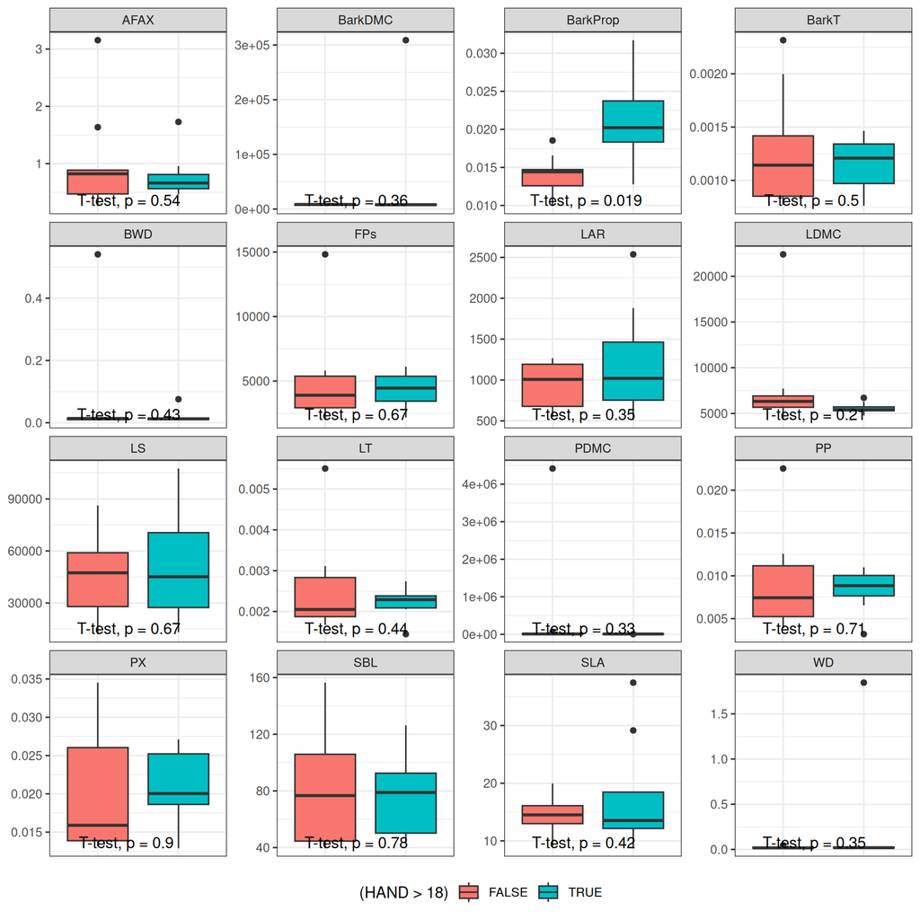

```r
cwv |>
  gather(trait, trait_value, -Plot) |>
  left_join(env) |>
  filter(!is.na(HAND)) |>
  ggplot(aes((HAND > 18), trait_value, fill = (HAND > 18))) +
  geom_boxplot() +
  facet_wrap(~ trait, scales = "free_y") +
  theme_bw() +
  theme(axis.title = element_blank(),
        legend.position = "bottom",
        axis.text.x = element_blank(),
        axis.ticks.x = element_blank()) +
  ggpubr::stat_compare_means(method = "t.test", label.y.npc = "bottom")
```

## Linear regressions

Finally, we performed linear regressions for each trait against two environmental variation variables, selected based on the co-variation of environmental variables: height above the nearest drainage (HAND) and phosphorus (P). We got 2 significant effects:

- BarkProp increases with HAND
- PX decreases with P

Figures and tables below are showing:

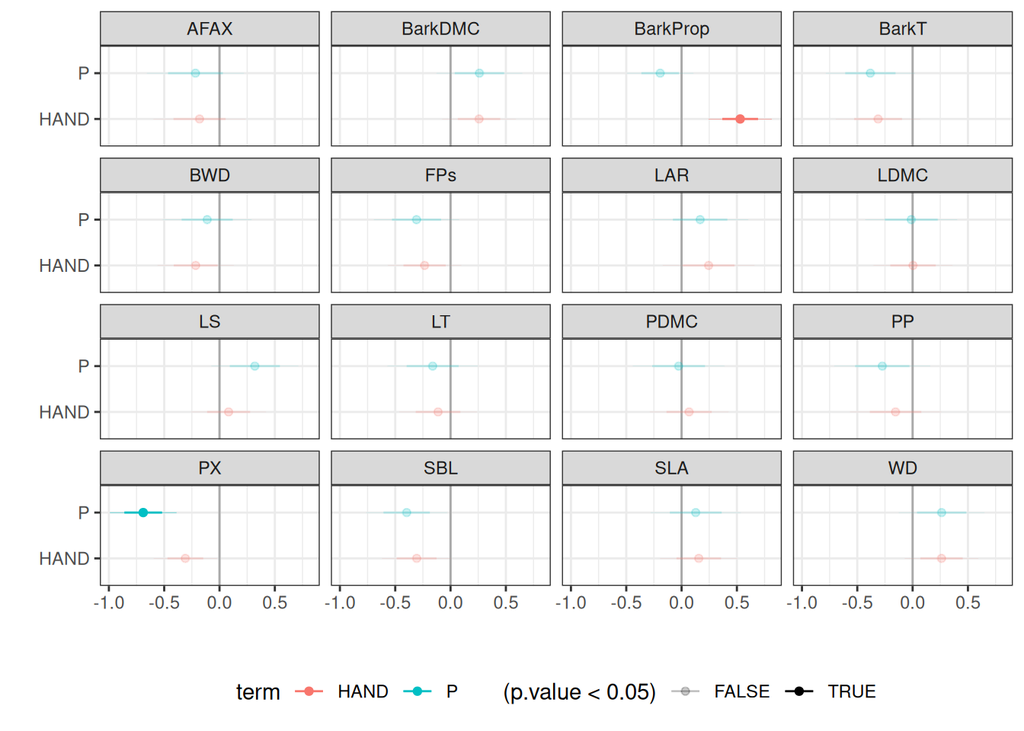

```r
all_reg <- cwv |>
  mutate(across(-Plot, ~ as.numeric(scale(.x)))) |>
  gather(trait, trait_value, -Plot) |>
  left_join(env |>
              mutate(HAND = log(HAND)) |>
              mutate(across(Altitude:Sand, ~ as.numeric(scale(.x))))) |>
  group_by(trait) %>%
  nest() |>
  mutate(
    model = map(data, ~ lm(trait_value ~ HAND + P, data = .x))
  )
all_reg |>
  mutate(coefs = map(model, ~broom::tidy(.x, conf.int = TRUE, conf.level = 0.90))) %>%
  unnest(coefs) |>
  select(-data, -model) |>
  filter(term != "(Intercept)") |>
  ggplot(aes(x = term, col = term, alpha = (p.value < 0.05))) +
  geom_hline(yintercept = 0, col = "darkgrey") +
  geom_point(aes(y = estimate)) +
  geom_segment(aes(y = estimate - std.error, yend = estimate + std.error)) +
  geom_segment(aes(y = conf.low, yend = conf.high), linewidth = .1) +
  facet_wrap(~trait) +
  theme_bw() +
  coord_flip() +
  xlab("") + ylab("") +
  scale_alpha_manual(values = c(0.2, 1)) +
  theme(legend.position = "bottom")
```

```r
sjPlot::tab_model(filter(all_reg, trait %in% c("BarkProp", "PX"))$model,
                  dv.labels = filter(all_reg, trait %in% c("BarkProp", "PX"))$trait)
```

|  | BarkProp |  |  | PX |  |  |
| --- | --- | --- | --- | --- | --- | --- |
| Predictors | Estimates | CI | p | Estimates | CI | p |
| (Intercept) | 0.11 | -0.29 – 0.52 | 0.562 | -0.21 | -0.62 – 0.20 | 0.281 |
| HAND | 0.53 | 0.18 – 0.88 | **0.006** | -0.31 | -0.66 – 0.04 | 0.079 |
| P | -0.19 | -0.56 – 0.17 | 0.276 | -0.69 | -1.06 – -0.32 | **0.001** |
| Observations | 16 |  |  | 16 |  |  |
| R<sup>2</sup> / R<sup>2</sup> adjusted | 0.563 / 0.496 |  |  | 0.562 / 0.494 |  |  |

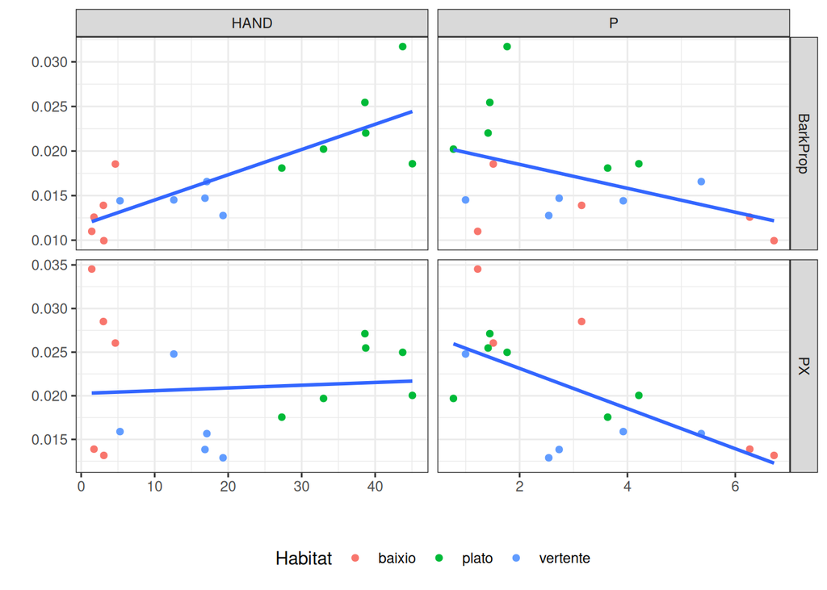

```r
cwv |>
  gather(trait, trait_value, -Plot) |>
  left_join(env) |>
  gather(env, env_value, -Plot, -Habitat, -trait, -trait_value) |>
  filter(trait %in% c("BarkProp", "PX"),
         env %in% c("HAND", "P")) |>
  ggplot(aes(env_value, trait_value)) +
  geom_point(aes(col = Habitat)) +
  theme_bw() +
  facet_grid(trait ~ env, scales = "free") +
  geom_smooth(method = "lm", se = FALSE) +
  ylab("") + xlab("") +
  theme(legend.position = "bottom")
```

# Analyses - SES

We explored the variation in functional composition of communities according to local co-variates. We designed a null model that randomizes trait values among species, breaking the link between environment and local functional composition, while maintaining the spatial distribution of communities and species’ abundance. We derived 999 varying randomized CWM values and calculated the standardized effect sizes (SES) quantifying the deviation of observed values from the null distribution, as

$$SES = \frac{CWM_{obs}-\overline{CWM_{null}}}{\sigma_{null}}$$

where CWM<sub>obs</sub> was the observed CWM, and $\overline{CWM_{null}}$ and $\sigma_{null}$ were the mean and standard deviation of the null distribution, respectively.

## Abundances

We need first to register species’ abundance per community:

```r
abund <- com |>
  group_by(Plot, Species) |>
  summarise(N = n()) |>
  group_by(Plot) |>
  mutate(Abundance = N/sum(N))
abund |>
  select(-N) |>
  pivot_wider(names_from = Plot, values_from = Abundance) |>
  head() |>
  kable()
```

| Species | LO2T1000 | LO2T2000 | LO3T1500 | LO3T2500 | LO3T3500 | LO3T4500 | LO4T0500 | LO4T2500 | LO4T3500 | LO4T4500 | LO5T3500 | LO5T5500 | LO6T0500 | LO6T1500 | LO6T2500 | LO7T0500 | LO7T1500 | LO7T3500 | LO8T0500 | LO8T1500 |
| --- | --- | --- | --- | --- | --- | --- | --- | --- | --- | --- | --- | --- | --- | --- | --- | --- | --- | --- | --- | --- |
| Alibertia myrciifolia | 0.0114943 |  |  |  |  |  |  |  |  |  |  |  |  |  |  |  |  |  |  |  |
| Andira micrantha | 0.0114943 |  |  |  |  |  |  |  |  | 0.0128205 |  |  |  |  | 0.0093458 |  | 0.0107527 | 0.0108696 |  | 0.0068493 |
| Calyptranthes cuspidata | 0.0114943 |  |  | 0.0121951 |  |  |  |  |  | 0.0128205 |  | 0.010989 |  | 0.0091743 |  |  |  | 0.0108696 |  |  |
| Carpotroche crispidentata | 0.0114943 |  |  |  |  |  |  |  |  |  |  |  |  |  |  |  | 0.0107527 |  |  |  |
| Casearia javitensis | 0.0114943 |  |  |  |  |  |  |  |  |  |  |  |  |  |  |  |  |  |  |  |
| Cybianthus na | 0.0114943 |  |  |  |  |  |  |  |  |  |  |  |  |  |  |  |  |  |  |  |

## Functional traits

Then we need to build a trait x species table.

```r
ft <- com |>
  select(-Tree, -Plot, -Height, -LightTree) |>
  group_by(Species) |>
  summarise_all(mean, na.rm = TRUE)
ft |>
  head() |>
  kable()
```

| Species | SBL | WD | BarkDMC | BWD | PP | PX | BarkProp | BarkT | AFAX | LAR | LS | LT | SLA | LDMC | PDMC | FPs |
| --- | --- | --- | --- | --- | --- | --- | --- | --- | --- | --- | --- | --- | --- | --- | --- | --- |
| Abarema laeta | 22.030000 | 0.61000 | 453.0300 | 0.5300000 | 0.1300000 | 0.7400000 | 0.1300000 | 0.0090000 | 1.630000 | 160.2000 | 91.5100 | 0.1500000 | 20.33 | 383.310 | 378.0300 | 340.4800 |
| Adiscanthus fusciflorus | 6.825333 | 0.59375 | 303.2947 | 0.4541176 | 0.1207143 | 0.3971429 | 0.4807143 | 0.0907407 | 2.007692 | 100.4343 | 221.2250 | 0.2326316 | 12.58 | 306.560 | 257.2894 | 163.1976 |
| Aiouea myristicoides | 12.180000 | 0.47000 | 381.0900 | 0.5200000 |  |  |  |  |  |  | 158.8500 | 0.2100000 | 11.98 | 426.930 | 285.5000 | 82.7000 |
| Alibertia myrciifolia | 18.060000 | 0.81000 | 440.8200 | 0.6500000 |  |  |  |  |  |  | 40.5200 | 0.2200000 | 11.50 | 460.930 | 466.0800 | 144.2000 |
| Amaioua corymbosa | 20.347500 | 0.68500 | 523.9525 | 0.5900000 | 0.1700000 | 0.5575000 | 0.2700000 | 0.0243750 | 1.390000 | 159.2667 | 40.6175 | 0.1150000 | 20.80 | 430.225 | 433.6000 | 250.4175 |
| Amaioua guianensis | 13.870000 | 0.75000 | 578.6800 | 0.6700000 | 0.1500000 | 0.4800000 | 0.3700000 | 0.0385800 | 1.670000 | 125.8200 | 50.5200 | 0.1400000 | 16.41 | 486.180 | 455.2100 | 190.1500 |

## Randomization

We randomize 999 times trait values among species, breaking the link between environment and local functional composition.

```r
ft_random <- ft |>
  mutate(Repetition = list(1:999), .before = Species) |>
  unnest(Repetition) |>
  arrange(Repetition, Species) |>
  group_by(Repetition) |>
  mutate(Species = sample(Species))
ft_random |>
  filter(Species == "Abarema laeta") |>
  head() |>
  kable()
```

| Repetition | Species | SBL | WD | BarkDMC | BWD | PP | PX | BarkProp | BarkT | AFAX | LAR | LS | LT | SLA | LDMC | PDMC | FPs |
| --- | --- | --- | --- | --- | --- | --- | --- | --- | --- | --- | --- | --- | --- | --- | --- | --- | --- |
| 1 | Abarema laeta | 10.15429 | 0.4871429 | 320.3486 | 0.8642857 | 0.1333333 | 0.65 | 0.22 | 0.03811 | 1.093333 | 121.84 | 414.3614 | 0.25 | 17.38 | 344.16 | 235.67 | 112.0057 |
| 2 | Abarema laeta | 14.12000 | 0.2800000 | 318.3700 | 0.3000000 | 0.2500000 | 0.39 | 0.36 | 0.05000 |  |  | 109.1500 | 0.20 | 14.07 | 366.68 | 289.51 | 149.5800 |
| 3 | Abarema laeta | 14.86000 | 0.6800000 | 386.8700 | 0.6300000 | 0.0700000 | 0.57 | 0.35 | 0.03700 | 1.350000 | 104.21 | 37.4400 | 0.14 | 12.75 | 568.47 | 554.35 | 353.7800 |
| 4 | Abarema laeta | 24.32000 | 0.6900000 | 457.6800 | 0.5800000 | 0.0900000 | 0.58 | 0.33 | 0.03500 | 1.120000 |  | 55.6800 | 0.14 |  |  |  | 186.3300 |
| 5 | Abarema laeta | 5.85000 | 0.7600000 | 397.9800 | 0.5700000 |  |  |  |  |  |  | 232.7700 | 0.24 | 9.58 | 390.24 | 335.99 | 179.1300 |
| 6 | Abarema laeta | 21.90000 | 0.5500000 | 430.0500 | 0.5000000 | 0.0400000 | 0.55 | 0.42 | 0.03875 | 1.790000 | 106.58 | 21.9700 | 0.21 | 12.62 | 459.86 | 481.01 | 169.8500 |

## Standardized Effect Sizes (SES)

We need first to compute null CWM for each randomization and then their means and standard deviations.

```r
cwm_null <- ft_random |>
  gather(Trait, Value, -Repetition, -Species) |>
  na.omit() |>
  left_join(abund) |>
  group_by(Repetition, Trait) |>
  summarise(CWMnull = weighted.mean(Value, Abundance)) |>
  group_by(Trait) |>
  summarise(CWMnull_sd = sd(CWMnull), CWMnull_mean = mean(CWMnull))
cwm_null |>
  head() |>
  kable()
```

| Trait | CWMnull_sd | CWMnull_mean |
| --- | --- | --- |
| AFAX | 0.0820268 | 1.6688889 |
| BWD | 0.0125033 | 0.5053776 |
| BarkDMC | 13.7666237 | 400.4192901 |
| BarkProp | 0.0109662 | 0.3465693 |
| BarkT | 0.0031179 | 0.0508194 |
| FPs | 4.8654623 | 192.7499424 |

Then we can use the formula to compute SES:

```r
ses <- ft |>
  gather(Trait, Value, -Species) |>
  na.omit() |>
  left_join(abund) |>
  group_by(Trait, Plot) |>
  summarise(CWM = weighted.mean(Value, Abundance)) |>
  left_join(cwm_null) |>
  mutate(SES = (CWM - CWMnull_mean)/CWMnull_sd) |>
  select(Plot, Trait, SES) |>
  pivot_wider(names_from = Trait, values_from = SES)
ses |>
  head() |>
  kable()
```

| Plot | AFAX | BWD | BarkDMC | BarkProp | BarkT | FPs | LAR | LDMC | LS | LT | PDMC | PP | PX | SBL | SLA | WD |
| --- | --- | --- | --- | --- | --- | --- | --- | --- | --- | --- | --- | --- | --- | --- | --- | --- |
| LO2T1000 | -0.5270272 | 3.069278 | 3.355324 | -1.3599792 | -0.9194636 | 2.9586192 | -1.501977 | 1.903838 | 0.3409906 | -1.7959046 | -0.1576536 | 0.5246800 | 0.7999367 | -1.556430 | -0.418225 | 2.217611 |
| LO2T2000 | -1.0881365 | 2.584093 | 1.223946 | 0.0502987 | 0.1459119 | 2.4013237 | -1.530168 | 2.172458 | -0.0822859 | -1.0367341 | -0.2978432 | -2.5880112 | 1.7978368 | -1.383383 | -1.558331 | 2.841232 |
| LO3T1500 | -1.1779612 | 2.225725 | 1.823975 | -0.9948837 | 1.1263806 | -0.4091126 | -2.743018 | 2.969554 | 1.0403910 | -0.1933219 | -0.3238107 | 0.0154704 | 0.7866573 | -1.803010 | -3.371805 | 1.057683 |
| LO3T2500 | 1.8698069 | 1.424853 | 1.478665 | 3.7205507 | 2.9273840 | 2.0150613 | -4.271549 | 2.139993 | -1.0306125 | 1.0180267 | -0.3234416 | -1.1787321 | -2.3499965 | -1.978382 | -3.402221 | 1.663511 |
| LO3T3500 | 3.9503572 | -7.203943 | -5.054234 | 1.1828679 | 1.8753974 | -0.4518609 | 3.772040 | -6.564015 | -0.2434251 | 3.1321784 | -1.3264484 | 5.3583231 | -4.7114773 | 1.751315 | 1.472312 | -6.578929 |
| LO3T4500 | 0.4135153 | 2.297635 | 1.243130 | 1.9903839 | 0.4205991 | 5.2471211 | 1.653656 | 1.476298 | -1.2140687 | -5.3647465 | -0.2348320 | -3.4396729 | 0.7117808 | -2.543515 | 2.622411 | 2.629707 |

## Linear regressions

- AFAX decreases with HAND
- BarkDMC increases with HAND
- LDMC increases with HAND
- LT decreases with HAND

Figures and tables below are showing:

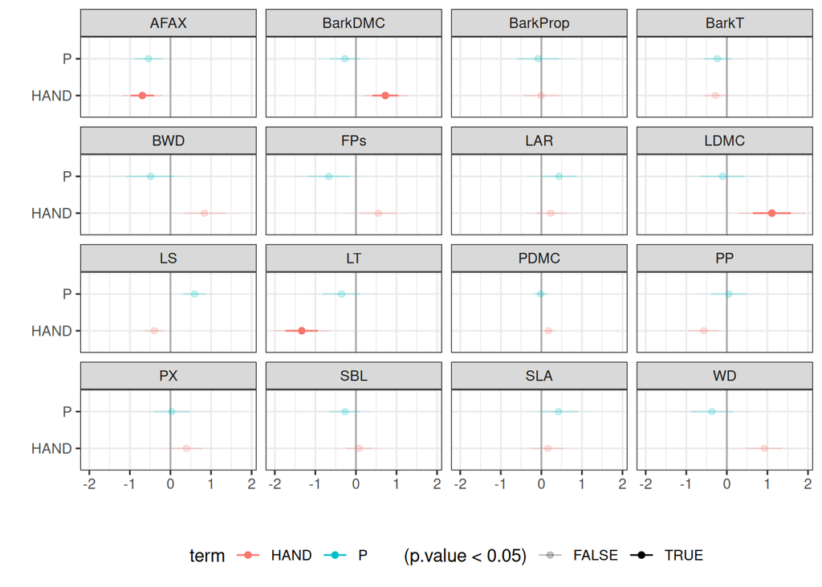

```r
all_reg <- ses |>
  gather(trait, trait_value, -Plot) |>
  left_join(env |>
              mutate(HAND = log(HAND)) |>
              mutate(across(Altitude:Sand, ~ as.numeric(scale(.x))))) |>
  group_by(trait) %>%
  nest() |>
  mutate(
    model = map(data, ~ lm(trait_value ~ HAND + P, data = .x))
  )
all_reg |>
  mutate(coefs = map(model, ~broom::tidy(.x, conf.int = TRUE, conf.level = 0.90))) %>%
  unnest(coefs) |>
  select(-data, -model) |>
  filter(term != "(Intercept)") |>
  ggplot(aes(x = term, col = term, alpha = (p.value < 0.05))) +
  geom_hline(yintercept = 0, col = "darkgrey") +
  geom_point(aes(y = estimate)) +
  geom_segment(aes(y = estimate - std.error, yend = estimate + std.error)) +
  geom_segment(aes(y = conf.low, yend = conf.high), linewidth = .1) +
  facet_wrap(~trait) +
  theme_bw() +
  coord_flip() +
  xlab("") + ylab("") +
  scale_alpha_manual(values = c(0.2, 1)) +
  theme(legend.position = "bottom")
```

```r
sjPlot::tab_model(filter(all_reg, trait %in% c("LT", "LDMC"))$model,
                  dv.labels = filter(all_reg, trait %in% c("LT", "LDMC"))$trait)
```

|  | LDMC |  |  | LT |  |  |
| --- | --- | --- | --- | --- | --- | --- |
| Predictors | Estimates | CI | p | Estimates | CI | p |
| (Intercept) | 1.41 | 0.19 – 2.64 | **0.026** | -1.67 | -2.70 – -0.63 | **0.004** |
| HAND | 1.11 | 0.12 – 2.10 | **0.030** | -1.33 | -2.18 – -0.49 | **0.004** |
| P | -0.10 | -1.26 – 1.05 | 0.852 | -0.35 | -1.33 – 0.63 | 0.456 |
| Observations | 20 |  |  | 20 |  |  |
| R<sup>2</sup> / R<sup>2</sup> adjusted | 0.269 / 0.183 |  |  | 0.398 / 0.327 |  |  |

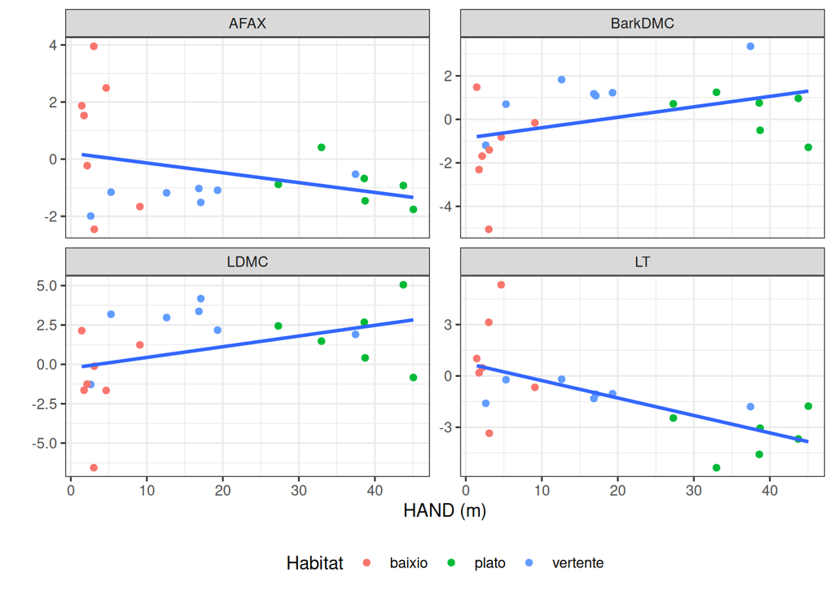

```r
ses |>
  gather(trait, trait_value, -Plot) |>
  left_join(env) |>
  gather(env, env_value, -Plot, -Habitat, -trait, -trait_value) |>
  filter(trait %in% c("AFAX", "BarkDMC", "LDMC", "LT"),
         env == "HAND") |>
  ggplot(aes(env_value, trait_value)) +
  geom_point(aes(col = Habitat)) +
  theme_bw() +
  facet_wrap(~ trait, scales = "free_y") +
  geom_smooth(method = "lm", se = FALSE) +
  ylab("") + xlab("HAND (m)") +
  theme(legend.position = "bottom")
```

# Conclusion

Topography with HAND is a strong driver of trait variations among communities.

## References

Schietti, Juliana, Thaise Emilio, Camilo D. Rennó, et al. 2013. “Vertical Distance from Drainage Drives Floristic Composition Changes in an Amazonian Rainforest.” *Plant Ecology & Diversity* 7 (1-2): 241–53. https://doi.org/10.1080/17550874.2013.783642.

Schmitt, Sylvain, Valérie Raevel, Maxime Réjou-Méchain, et al. 2021. “Canopy and Understorey Tree Guilds Respond Differently to the Environment in an Indian Rain Forest.” *Journal of Vegetation Science* 32 (5). https://doi.org/10.1111/jvs.13075.